# NYDP Shooting Incident Data

## Initial Analysis

With the data visualized, let’s perform a basic analysis to identify any immediate trends or outliers.

```r
# Summarizing incidents by borough and victim's age group
borough_summary <- shooting_data %>%
  group_by(BORO, VIC_AGE_GROUP) %>%
  summarise(Incidents = n(), .groups = 'drop')

# Displaying the summarized data
print(borough_summary)
```

```
## # A tibble: 28 × 3
##    BORO     VIC_AGE_GROUP Incidents
##    <fct>    <chr>             <int>
##  1 BRONX    18-24               268
##  2 BRONX    25-44               494
##  3 BRONX    45-64                97
##  4 BRONX    65+                  12
##  5 BRONX    <18                  90
##  6 BROOKLYN 18-24               243
##  7 BROOKLYN 25-44               514
##  8 BROOKLYN 45-64               101
##  9 BROOKLYN 65+                  15
## 10 BROOKLYN <18                  92
## # ℹ 18 more rows
```

## Predictive Modeling

We build upon these observations in the following discussion by applying a logistic regression model to the factors that affect shooting incidents in NYC. The model should explain the significant predictors of whether or not a shooting incident is likely to be classified as a statistical murder.

### Preparing the Data for Modeling

First, we need to prepare our dataset by selecting relevant features and ensuring that our target variable is suitable for logistic regression.

```r
# Selecting relevant columns and dropping NA values
model_data <- shooting_data %>%
  select(INCIDENT_KEY, BORO, OCCUR_TIME, PERP_AGE_GROUP, PERP_SEX, PERP_RACE, STATISTICAL_MURDER_FLAG) %>%
  drop_na()

# Converting the target variable to a binary factor
model_data$STATISTICAL_MURDER_FLAG <- as.factor(model_data$STATISTICAL_MURDER_FLAG)
```

## Creating the Logistic Regression Model

We will create a logistic regression model to estimate the probability of an incident being a statistical murder based on the perpetrator’s demographics and the location of the incident.

```r
# Fitting the logistic regression model
model <- glm(STATISTICAL_MURDER_FLAG ~ BORO + PERP_AGE_GROUP + PERP_SEX + PERP_RACE,
             family = binomial(link = "logit"), data = model_data)

# Displaying the model summary
summary(model)
```

```
##
## Call:
## glm(formula = STATISTICAL_MURDER_FLAG ~ BORO + PERP_AGE_GROUP +
##     PERP_SEX + PERP_RACE, family = binomial(link = "logit"),
##     data = model_data)
##
## Coefficients: (2 not defined because of singularities)
##                                     Estimate Std. Error z value Pr(>|z|)
## (Intercept)                        -1.650432   0.108703 -15.183  < 2e-16 ***
## BOROBROOKLYN                       -0.103465   0.117334  -0.882 0.377883
## BOROMANHATTAN                      -0.150156   0.140542  -1.068 0.285339
## BOROQUEENS                         -0.239525   0.151068  -1.586 0.112843
## BOROSTATEN ISLAND                   0.088356   0.320525   0.276 0.782808
## PERP_AGE_GROUP<18                   0.265382   0.240520   1.103 0.269868
## PERP_AGE_GROUP18-24                 0.637354   0.174745   3.647 0.000265 ***
## PERP_AGE_GROUP25-44                 0.735227   0.162381   4.528 5.96e-06 ***
## PERP_AGE_GROUP45-64                 1.330545   0.211206   6.300 2.98e-10 ***
## PERP_AGE_GROUP65+                   0.002069   1.081126   0.002 0.998473
## PERP_SEXF                           0.108677   0.277587   0.392 0.695423
## PERP_SEXM                                 NA         NA      NA       NA
## PERP_RACEASIAN / PACIFIC ISLANDER  -0.069548   0.460796  -0.151 0.880031
## PERP_RACEBLACK                     -0.190623   0.144327  -1.321 0.186578
## PERP_RACEBLACK HISPANIC             0.033262   0.209414   0.159 0.873799
## PERP_RACEUNKNOWN                  -11.500703 324.743744  -0.035 0.971749
## PERP_RACEWHITE                     -1.121767   0.637276  -1.760 0.078365 .
## PERP_RACEWHITE HISPANIC                   NA         NA      NA       NA
## ---
## Signif. codes:  0 '***' 0.001 '**' 0.01 '*' 0.05 '.' 0.1 ' ' 1
##
## (Dispersion parameter for binomial family taken to be 1)
##
##     Null deviance: 2943.9  on 2906  degrees of freedom
## Residual deviance: 2877.3  on 2891  degrees of freedom
## AIC: 2909.3
##
## Number of Fisher Scoring iterations: 11
```

## Model Diagnostics

To assess the quality of our model, we’ll look at the residuals and check for any significant outliers or leverage points that could affect our predictions.

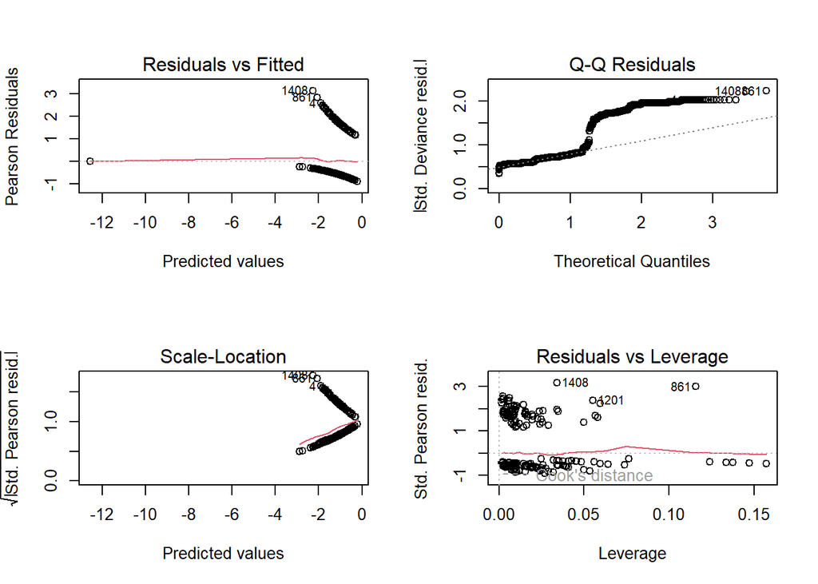

```r
# Checking residuals
par(mfrow = c(2, 2))
plot(model)
```

## Interpretation of Results

The coefficients from the logistic regression model afford a view of exactly how each factor, such as borough or perpetrator race, adjusts the odds of an incident being classified as a murder. Note that a positive coefficient increases the odds of an incident being a murder, while negative coefficients decrease such odds.

## Further Questions

Further visualizations and analyses often lead to more questions, such as:

Let these questions help dive into your data deeper to possibly influence strategies in public safety.

## Conclusion and Bias Identification

### Sources of Bias in the Data

There are several potential sources in this dataset and the analysis here:

1. **Data Bias**: Not every shooting incident gets reported similarly in all boroughs, hence this could be a reason for the under-or over-representation of certain areas.
2. **Data Collection Bias**: The practices and priorities of the data collectors themselves may affect the data collection, with a possible consequence of distortion in the direction of more serious incidents or incidents with certain kinds of demographic involvement.
3. **Selection Bias**: The fact that this dataset is public means sensitive or unreleased cases are excluded, which could in itself be a bias that shifts the outcome of the general results.

### Personal Bias and Mitigation

With this in mind, as the analyst, my background and experiences will serve to predispose me toward certain ways of interpreting the data. In other words, I can be prone to underlining those findings that confirm my preexisting beliefs—for instance, whether crime rate is higher in specific neighborhoods or among some types of demographics.

The following steps have been taken to reduce these biases:

- **Multiplicity of Data Sources**: Findings, as much as possible, are cross-checked against other data sources or studies to be consistent and reliable.
- **Peer Review**: Engaging colleagues and stakeholders in reviewing the process of analysis and findings that challenge and refine conclusions.
- **Open Methodology**: This means that the analytical process is fully transparent, open to scrutiny, and thereby documented step by step, right from cleaning up the data to the final outputs.

### Further Reflections

This analysis therefore raises some questions, such as socioeconomic pressures on shooting cases, seasonal trends, and effective law enforcement strategies among others, which call for in-depth studies. It is now much easier to get an insight and deepen our strategies for improvement in public safety.

Moving forward, it is critical that these biases are observed and a balancing view pursued to reflect the reality of crime in New York City. In other words, though data analysis provides insight, it is only as good as the underlying data and methodologies. Work to recognize and mitigate potential biases so the findings and recommendations provide value to positive change in public policy and community well-being.